# MATH2349 Semester 2, 2018

Assignment 3

Verity Miles(s3644459), Sam Holt (s3381728), Meg Cuddihy (s3608125)

17 October 2018

## Required packages

```r
library(readr)
library(readxl)
library(dplyr)
library(tidyr)
library(knitr)
library(mlr)
```

## Data

We have used two different datasets.

#### Data set 1: Education Levels

The first data set that we used comes from the 2016 Australian Census made available by the Australian Bureau of Statistics (ABS). We used a public TableBuilder account to extract education level for each SA1 within Victoria. [Click here for information on TableBuilder](https://auth.censusdata.abs.gov.au/webapi/jsf/login.xhtml). SA1s are the smallest geographic unit that the majority of census data is available at. They generally have a population of between 200 and 800 people. Click here for more information.

The columns in this data set are:

- SA1 7 digit code
- Postgraduate Degree Level
  - Doctoral Degree Level
  - Masters Degree Level
- Graduate Diploma and Graduate Certificate Level
- Bachelor Degree Level
- Advanced Diploma and Diploma Level
- Certificate III & IV Level
- Secondary Education Years 10 and above
- Certificate I &II Level
- Secondary Education Years 9 and below
- Supplementary Codes
- Not stated
- Not applicable
- Total

The different education levels are coded as per the Australian Classification of Education (ASCED) 2001. For more information click [here](http://www.abs.gov.au/ausstats/abs@.nsf/Latestproducts/1272.0Main%20Features12001?opendocument&tabname=Summary&prodno=1272.0&issue=2001&num=&view=).

When using data from the Australian Census it is important to remember that all data is self-reported. This means that care needs to be taken when making conclusions from this data source.

#### Data set 2: Geographic Look Up

The second data set that we used is a geographic lookup linking SA1s to local government areas (LGAs) and the Greater Capital City Statistical Area (GCCSA) of Greater Melbourne. We compiled this lookup using geographic files for SA1s and LGAs from the ABS and did a spatial join (within QGIS). [Click here for more information about QGIS](https://www.qgis.org/en/site/).

The columns in this data set are:

- SA1_7DIG16
  - 7 digit unique identifier for SA1
  - Should be numeric
- LGA_NAME17
  - Local council name
- MetroMelbourne
  - Indicator of whether the SA1 is within metropolitan Melbourne

  ```r
  education <- read_excel("allVic_education.xls", skip = 8, col_names = TRUE)
  head(education)
  ```

  | HEAP - 1 Digit Level | X__1 | Postgraduate Degree Level | Graduate Diploma and Graduate Certificate Level | Bachelor Degree Level | Advanced Diploma and Diploma Level | Certificate III & IV Level | Secondary Education - Years 10 and above | Certificate I & II Level | Secondary Education - Years 9 and below | Supplementary Codes | Not stated | Not applicable | Total |
  | --- | --- | --- | --- | --- | --- | --- | --- | --- | --- | --- | --- | --- | --- |
  | NA | SA1 (UR) | NA | NA | NA | NA | NA | NA | NA | NA | NA | NA | NA | NA |
  | NA | 2100101 | 22 | 12 | 44 | 31 | 61 | 111 | 0 | 25 | 10 | 32 | 82 | 430 |
  | NA | 2100102 | 0 | 0 | 24 | 16 | 23 | 58 | 0 | 52 | 3 | 21 | 22 | 217 |
  | NA | 2100105 | 9 | 5 | 30 | 31 | 46 | 86 | 0 | 19 | 11 | 31 | 36 | 297 |
  | NA | 2100106 | 13 | 16 | 69 | 31 | 75 | 154 | 0 | 37 | 8 | 48 | 110 | 564 |
  | NA | 2100107 | 12 | 8 | 45 | 22 | 54 | 94 | 0 | 51 | 7 | 34 | 51 | 365 |

  ```r
  geo_lookup <- read_csv("SA1_LGA_LookUp.csv")
  head(geo_lookup)
  ```

  | SA1_7DIG16 | LGA_NAME17 | MetroMelbourne |
  | --- | --- | --- |
  | 2115615 | Manningham (C) | Greater Melbourne |
  | 2115616 | Manningham (C) | Greater Melbourne |
  | 2115617 | Manningham (C) | Greater Melbourne |
  | 2115618 | Manningham (C) | Greater Melbourne |
  | 2115619 | Manningham (C) | Greater Melbourne |
  | 2115620 | Manningham (C) | Greater Melbourne |

  After importing the education data set, an error occurred. At the bottom of the dataset, there is a disclaimer with extra informtion. The error states that this information is not imported. This is not an issue as we didn’t need that data.

## Understand

Summarise the types of variables and data structures, check the attributes in the data. In addition to the R codes and outputs, explain briefly the steps that you have taken. In this section, show that you have fulfilled minimum requirements 2-4.

#### Data set 1: Education Levels

The first data set that we used comes from the 2016 Australian Census made available by the Australian Bureau of Statistics (ABS). We used a public TableBuilder account to extract education level for each SA1 within Victoria. [Click here for information on TableBuilder](https://auth.censusdata.abs.gov.au/webapi/jsf/login.xhtml). SA1s are the smallest geographic unit that the majority of census data is available at. They generally have a population of between 200 and 800 people. Click here for more information.

##### Types of variables

Character:

- SA1 7 digit code

This variable will need to be converted to a numeric data type so that the data set can be joined with the other data. The SA1 7 digit code is a unique identifier and should not be summed or averaged.

Numeric:

- Postgraduate Degree Level
  - Doctoral Degree Level
  - Masters Degree Level
- Graduate Diploma and Graduate Certificate Level
- Bachelor Degree Level
- Advanced Diploma and Diploma Level
- Certificate III & IV Level
- Secondary Education Years 10 and above
- Certificate I &II Level
- Secondary Education Years 9 and below
- Supplementary Codes
- Not stated
- Not applicable
- Total

The values in these columns are a numeric count of people in each statistical area that have achieved a certain level of education. The levels of education are suitable for creating an ordered factor variable as there is a clear, sensible ordering of each level of education. Before this can be done, the data must be gathered together in a single column. This will be done in the next step.

#### Data set 2: Geographic Look Up - Types of variables

Integer:

- SA1_7DIG16

Character:

- LGA_NAME17
- MetroMelbourne

The values in this column are categorical data so character is the correct data type.

```r
#Education Levels

head(education) #First column and first rows contain no data and need to be trimmed.
```

| HEAP - 1 Digit Level | X__1 | Postgraduate Degree Level | Graduate Diploma and Graduate Certificate Level | Bachelor Degree Level | Advanced Diploma and Diploma Level | Certificate III & IV Level | Secondary Education - Years 10 and above | Certificate I & II Level | Secondary Education - Years 9 and below | Supplementary Codes | Not stated | Not applicable | Total |
| --- | --- | --- | --- | --- | --- | --- | --- | --- | --- | --- | --- | --- | --- |
| NA | SA1 (UR) | NA | NA | NA | NA | NA | NA | NA | NA | NA | NA | NA | NA |
| NA | 2100101 | 22 | 12 | 44 | 31 | 61 | 111 | 0 | 25 | 10 | 32 | 82 | 430 |
| NA | 2100102 | 0 | 0 | 24 | 16 | 23 | 58 | 0 | 52 | 3 | 21 | 22 | 217 |
| NA | 2100105 | 9 | 5 | 30 | 31 | 46 | 86 | 0 | 19 | 11 | 31 | 36 | 297 |
| NA | 2100106 | 13 | 16 | 69 | 31 | 75 | 154 | 0 | 37 | 8 | 48 | 110 | 564 |
| NA | 2100107 | 12 | 8 | 45 | 22 | 54 | 94 | 0 | 51 | 7 | 34 | 51 | 365 |

```r
tail(education) #Extra rows at bottom of the data frame with no data, need to be trimmed.
```

| HEAP - 1 Digit Level | X__1 | Postgraduate Degree Level | Graduate Diploma and Graduate Certificate Level | Bachelor Degree Level | Advanced Diploma and Diploma Level | Certificate III & IV Level | Secondary Education - Years 10 and above | Certificate I & II Level | Secondary Education - Years 9 and below | Supplementary Codes | Not stated | Not applicable | Total |
| --- | --- | --- | --- | --- | --- | --- | --- | --- | --- | --- | --- | --- | --- |
| NA | NA | NA | NA | NA | NA | NA | NA | NA | NA | NA | NA | NA | NA |
| NA | NA | NA | NA | NA | NA | NA | NA | NA | NA | NA | NA | NA | NA |
| NA | Cells in this table have been randomly adjusted to avoid the release of confidential data. No reliance should be placed on small cells. | NA | NA | NA | NA | NA | NA | NA | NA | NA | NA | NA | NA |
| NA | NA | NA | NA | NA | NA | NA | NA | NA | NA | NA | NA | NA | NA |
| NA | NA | NA | NA | NA | NA | NA | NA | NA | NA | NA | NA | NA | NA |
| NA | NA | NA | NA | NA | NA | NA | NA | NA | NA | NA | NA | NA | NA |

```r
dim(education) #14 columns and 14,081 rows
```

```
## [1] 14081    14
```

```r
str(education) #One logical class column with no data. One character column with no header (X__1), will need to be renamed to SA1 and set to numeric so this dataset can be joined to others. The other 12 columns are numeric, containing counts of people with varying levels of educational qualifications in each statistical area.
```

```
## Classes 'tbl_df', 'tbl' and 'data.frame':    14081 obs. of  14 variables:
##  $ HEAP - 1 Digit Level                           : logi  NA NA NA NA NA NA ...
##  $ X__1                                           : chr  "SA1 (UR)" "2100101" "2100102" "2100105" ...
##  $ Postgraduate Degree Level                      : num  NA 22 0 9 13 12 20 12 14 10 ...
##  $ Graduate Diploma and Graduate Certificate Level: num  NA 12 0 5 16 8 17 23 13 16 ...
##  $ Bachelor Degree Level                          : num  NA 44 24 30 69 45 67 48 63 37 ...
##  $ Advanced Diploma and Diploma Level             : num  NA 31 16 31 31 22 37 41 47 21 ...
##  $ Certificate III & IV Level                     : num  NA 61 23 46 75 54 96 74 56 54 ...
##  $ Secondary Education - Years 10 and above       : num  NA 111 58 86 154 94 185 135 138 103 ...
##  $ Certificate I & II Level                       : num  NA 0 0 0 0 0 0 0 0 0 ...
##  $ Secondary Education - Years 9 and below        : num  NA 25 52 19 37 51 54 45 29 23 ...
##  $ Supplementary Codes                            : num  NA 10 3 11 8 7 17 16 9 4 ...
##  $ Not stated                                     : num  NA 32 21 31 48 34 38 47 19 19 ...
##  $ Not applicable                                 : num  NA 82 22 36 110 51 155 120 114 93 ...
##  $ Total                                          : num  NA 430 217 297 564 365 681 571 504 380 ...
```

```r
names(education) #X__1 will need to be changed to SA1. The other headers are varying levels of education qualifications, making this data a good candidate for gathering into a single column as they all pertain to the same type of information.
```

```
##  [1] "HEAP - 1 Digit Level"
##  [2] "X__1"
##  [3] "Postgraduate Degree Level"
##  [4] "Graduate Diploma and Graduate Certificate Level"
##  [5] "Bachelor Degree Level"
##  [6] "Advanced Diploma and Diploma Level"
##  [7] "Certificate III & IV Level"
##  [8] "Secondary Education - Years 10 and above"
##  [9] "Certificate I & II Level"
## [10] "Secondary Education - Years 9 and below"
## [11] "Supplementary Codes"
## [12] "Not stated"
## [13] "Not applicable"
## [14] "Total"
```

```r
class(education) #Class of object is a data frame as expected.
```

```
## [1] "tbl_df"     "tbl"        "data.frame"
```

```r
#Geographical Data

head(geo_lookup) #No extra columns or rows to trim.
```

| SA1_7DIG16 | LGA_NAME17 | MetroMelbourne |
| --- | --- | --- |
| 2115615 | Manningham (C) | Greater Melbourne |
| 2115616 | Manningham (C) | Greater Melbourne |
| 2115617 | Manningham (C) | Greater Melbourne |
| 2115618 | Manningham (C) | Greater Melbourne |
| 2115619 | Manningham (C) | Greater Melbourne |
| 2115620 | Manningham (C) | Greater Melbourne |

```r
tail(geo_lookup) #No extra columns or rows to trim. A few missing values are visible.
```

| SA1_7DIG16 | LGA_NAME17 | MetroMelbourne |
| --- | --- | --- |
| 2110407 | NA | Rest of Vic. |
| 2110407 | NA | Rest of Vic. |
| 2110407 | NA | Rest of Vic. |
| 2148014 | NA | Rest of Vic. |
| 2140636 | Murray River (A) | Rest of Vic. |
| 2141338 | Murray River (A) | Rest of Vic. |

```r
dim(geo_lookup) #3 columns and 14,382 rows - more rows than the education data. Will consider this when choosing the type of join to use.
```

```
## [1] 14382     3
```

```r
str(geo_lookup) #First column is SA1 values which are integers. Second column is LGA names which are characters. The third column has Metropolitan Melbourne Areas which are also characters.
```

```
## Classes 'tbl_df', 'tbl' and 'data.frame':    14382 obs. of  3 variables:
##  $ SA1_7DIG16    : int  2115615 2115616 2115617 2115618 2115619 2115620 2115621 2115622 2115623 2115624 ...
##  $ LGA_NAME17    : chr  "Manningham (C)" "Manningham (C)" "Manningham (C)" "Manningham (C)" ...
##  $ MetroMelbourne: chr  "Greater Melbourne" "Greater Melbourne" "Greater Melbourne" "Greater Melbourne" ...
##  - attr(*, "spec")=List of 2
##   ..$ cols   :List of 3
##   .. ..$ SA1_7DIG16    : list()
##   .. .. ..- attr(*, "class")= chr  "collector_integer" "collector"
##   .. ..$ LGA_NAME17    : list()
##   .. .. ..- attr(*, "class")= chr  "collector_character" "collector"
##   .. ..$ MetroMelbourne: list()
##   .. .. ..- attr(*, "class")= chr  "collector_character" "collector"
##   ..$ default: list()
##   .. ..- attr(*, "class")= chr  "collector_guess" "collector"
##   ..- attr(*, "class")= chr "col_spec"
```

```r
names(geo_lookup) #Names can be more neatly given for the SA1 and LGA variables.
```

```
## [1] "SA1_7DIG16"     "LGA_NAME17"     "MetroMelbourne"
```

```r
class(geo_lookup) #Class is data frame, as expected.
```

```
## [1] "tbl_df"     "tbl"        "data.frame"
```

## Tidy & Manipulate Data I

Check if the data conforms the tidy data principles. If your data is not in a tidy format, reshape your data into a tidy format (minimum requirement #5). In addition to the R codes and outputs, explain everything that you do in this step.

#### Tidy Data Principles:

1. Each variable must have its own column. - population needs to have its own column* Not tidy
2. Each observation must have its own row.
3. Each value must have its own cell.

The data sets do generally conform to the tidy data principles. However, it could be argued that the levels of education in the Education Levels data set qualify as a single variable, rather than a set of different variables. To address this, the gather function has been applied to all the education levels to bring them into a single column called Ed_level. Now the data set is comprised of three attributes, statistical area (SA1), level of education and a count of people in each SA1 that meet a particular level of education.

As mentioned in the previous section, the education level variable is a good candidate for creating an ordered factor variable as there is a naturally ordering of education levels. Education levels were labelled and ordered. Note that some observations had “Not Stated” and “Not Applicable” for education level. These have been ordered last in the factor ordering.

Now that the Education Levels data is tidy, we have joined it with the Local Government Area lookup data. Now we are able to access how many people in each LGA achieved each particular level of education. In order to do this, SA1 has been converted to a numeric variable in the Education Level data so that it is compatible with the LGA Lookup dataset. A left join was chosen, prioritising the education data on the left hand side as we want to be able to see as many LGAs for each observation in the Education Levels as we can.

The LGA variable in the LGA Lookup data set is called “LGA_NAME17” which is the metadata label used by the source (ABS). The column name has been changed to LGA which is simpler for users to read.

```r
#Education Data
education <- education[-1,-1] #Removing first row and column
colnames(education)[1] <- "SA1" #The first column has no header. Setting column header to SA1.
totalrow <- which(education$SA1 == 'Total') #Add a totals row at the bottom of the data frame.
education <- education[1:totalrow - 1,] #Removing empty rows at end of data frame.


edu_tidy <- gather(education, "Ed_level", "People", 2:length(education)) #Gathering column variables into a single row

head(edu_tidy)
```

| SA1 | Ed_level | People |
| --- | --- | --- |
| 2100101 | Postgraduate Degree Level | 22 |
| 2100102 | Postgraduate Degree Level | 0 |
| 2100105 | Postgraduate Degree Level | 9 |
| 2100106 | Postgraduate Degree Level | 13 |
| 2100107 | Postgraduate Degree Level | 12 |
| 2100108 | Postgraduate Degree Level | 20 |

```r
#Set education level to an ordered factor
edu_tidy <- edu_tidy %>% mutate(Ed_level = factor(Ed_level, levels = c("Postgraduate Degree Level", "Graduate Diploma and Graduate Certificate Level",
                                                                       "Bachelor Degree Level", "Advanced Diploma and Diploma Level", "Certificate III & IV Level",                                          "Secondary Education - Years 10 and above", "Certificate I & II Level", "Secondary Education - Years 9 and below",
                                                                       "Supplementary Codes", "Not stated", "Not applicable", "Total"),
                                                  labels = c("Postgraduate Degree Level", "Graduate Diploma and Graduate Certificate Level",
                                                             "Bachelor Degree Level", "Advanced Diploma and Diploma Level", "Certificate III & IV Level",
                                                             "Secondary Education - Years 10 and above", "Certificate I & II Level", "Secondary Education - Years 9 and below",
                                                             "Supplementary Codes", "Not stated", "Not applicable", "Total"),
                                                  ordered = TRUE))

edu_tidy <- transform(edu_tidy, SA1 = as.numeric(SA1)) #Setting the variable SA1 to numeric so it can be joined with other datasets.

#Local Government Area Lookup Data - provides a concordance between LGA and SA1 geographic areas
#Left Join Education Data to geographical area lookup to match observations to their LGA.

edu_tidy_join <- edu_tidy %>% left_join(geo_lookup[,c("SA1_7DIG16", "LGA_NAME17", "MetroMelbourne")], by = c("SA1" = "SA1_7DIG16"))

names(edu_tidy_join)[4] <- "LGA" #Change name from LGA_NAME17 to LGA for neatness.

head(edu_tidy_join)
```

|  | SA1 | Ed_level | People | LGA | MetroMelbourne |
| --- | --- | --- | --- | --- | --- |
| 1 | 2100101 | Postgraduate Degree Level | 22 | Ballarat (C) | Rest of Vic. |
| 2 | 2100102 | Postgraduate Degree Level | 0 | Ballarat (C) | Rest of Vic. |
| 3 | 2100105 | Postgraduate Degree Level | 9 | Ballarat (C) | Rest of Vic. |
| 4 | 2100106 | Postgraduate Degree Level | 13 | Ballarat (C) | Rest of Vic. |
| 5 | 2100107 | Postgraduate Degree Level | 12 | Ballarat (C) | Rest of Vic. |
| 6 | 2100108 | Postgraduate Degree Level | 20 | Ballarat (C) | Rest of Vic. |

```r
dim(edu_tidy_join)
```

```
## [1] 172632      5
```

```r
str(edu_tidy_join)
```

```
## 'data.frame':    172632 obs. of  5 variables:
##  $ SA1           : num  2100101 2100102 2100105 2100106 2100107 ...
##  $ Ed_level      : Ord.factor w/ 12 levels "Postgraduate Degree Level"<..: 1 1 1 1 1 1 1 1 1 1 ...
##  $ People        : num  22 0 9 13 12 20 12 14 10 9 ...
##  $ LGA           : chr  "Ballarat (C)" "Ballarat (C)" "Ballarat (C)" "Ballarat (C)" ...
##  $ MetroMelbourne: chr  "Rest of Vic." "Rest of Vic." "Rest of Vic." "Rest of Vic." ...
```

```r
glimpse(edu_tidy_join)
```

```
## Observations: 172,632
## Variables: 5
## $ SA1            <dbl> 2100101, 2100102, 2100105, 2100106, 2100107, 21...
## $ Ed_level       <ord> Postgraduate Degree Level, Postgraduate Degree ...
## $ People         <dbl> 22, 0, 9, 13, 12, 20, 12, 14, 10, 9, 6, 11, 14,...
## $ LGA            <chr> "Ballarat (C)", "Ballarat (C)", "Ballarat (C)",...
## $ MetroMelbourne <chr> "Rest of Vic.", "Rest of Vic.", "Rest of Vic.",...
```

```r
tail(edu_tidy_join)
```

|  | SA1 | Ed_level | People | LGA | MetroMelbourne |
| --- | --- | --- | --- | --- | --- |
| 172627 | 2148034 | Total | 276 | Warrnambool (C) | Rest of Vic. |
| 172628 | 2148035 | Total | 509 | Warrnambool (C) | Rest of Vic. |
| 172629 | 2979991 | Total | 0 | NA | NA |
| 172630 | 2979992 | Total | 24 | NA | NA |
| 172631 | 2979993 | Total | 4 | NA | NA |
| 172632 | 2949999 | Total | 7572 | NA | NA |

```r
summary(edu_tidy_join)
```

```
##       SA1                                                     Ed_level
##  Min.   :2100101   Postgraduate Degree Level                      :14386
##  1st Qu.:2113029   Graduate Diploma and Graduate Certificate Level:14386
##  Median :2124936   Bachelor Degree Level                          :14386
##  Mean   :2124742   Advanced Diploma and Diploma Level             :14386
##  3rd Qu.:2136022   Certificate III & IV Level                     :14386
##  Max.   :2979993   Secondary Education - Years 10 and above       :14386
##                    (Other)                                        :86316
##      People            LGA            MetroMelbourne
##  Min.   :   0.00   Length:172632      Length:172632
##  1st Qu.:  10.00   Class :character   Class :character
##  Median :  29.00   Mode  :character   Mode  :character
##  Mean   :  69.51
##  3rd Qu.:  67.00
##  Max.   :7572.00
##
```

## Tidy & Manipulate Data II

Create/mutate at least one variable from the existing variables (minimum requirement #6). In addition to the R codes and outputs, explain everything that you do in this step..

Now that we have Education Levels by LGA from joining the two data sets, we have grouped observations by LGA first, then by Education Level and then calculated a summary of the number of people which each qualification for each LGA.

```r
#Grouping by LGA
edu_by_LGA <- edu_tidy_join %>% group_by(LGA, Ed_level) %>% summarise(PeopleSum = sum(People))

head(edu_by_LGA)
```

| LGA | Ed_level | PeopleSum |
| --- | --- | --- |
| Alpine (S) | Postgraduate Degree Level | 223 |
| Alpine (S) | Graduate Diploma and Graduate Certificate Level | 297 |
| Alpine (S) | Bachelor Degree Level | 1257 |
| Alpine (S) | Advanced Diploma and Diploma Level | 1092 |
| Alpine (S) | Certificate III & IV Level | 2230 |
| Alpine (S) | Secondary Education - Years 10 and above | 3405 |

```r
glimpse(edu_by_LGA)
```

```
## Observations: 984
## Variables: 3
## $ LGA       <chr> "Alpine (S)", "Alpine (S)", "Alpine (S)", "Alpine (S...
## $ Ed_level  <ord> Postgraduate Degree Level, Graduate Diploma and Grad...
## $ PeopleSum <dbl> 223, 297, 1257, 1092, 2230, 3405, 3, 1128, 336, 1573...
```

## Scan I

Scan the data for missing values, inconsistencies and obvious errors. In this step, you should fulfil the minimum requirement #7. In addition to the R codes and outputs, explain how you dealt with these values.

```r
#Check the Education by LGA data frame for missing values using which(is.na()).

dim(edu_by_LGA) #There are 984 observations across the 3 variables.
```

```
## [1] 984   3
```

```r
which(is.na(edu_by_LGA)) #There are a number of missng values at the bottom of the data set.
```

```
##  [1] 973 974 975 976 977 978 979 980 981 982 983 984
```

```r
colSums(is.na(edu_by_LGA)) #The missing values are in the LGA column, meaning there are some observations of education level that do not have a corresponding LGA available.
```

```
##       LGA  Ed_level PeopleSum
##        12         0         0
```

```r
tail(edu_by_LGA)
```

| LGA | Ed_level | PeopleSum |
| --- | --- | --- |
| NA | Certificate I & II Level | 15 |
| NA | Secondary Education - Years 9 and below | 502 |
| NA | Supplementary Codes | 216 |
| NA | Not stated | 2207 |
| NA | Not applicable | 797 |
| NA | Total | 8119 |

```r
edu_by_LGA_NAs <- edu_tidy_join %>% group_by(Ed_level) %>% summarise(PeopleSum = sum(People)) #use to demonstrate it's okay to remove NAs

#Remove NAs
edu_by_LGA_complete <- edu_by_LGA[complete.cases(edu_by_LGA), ]

which(is.na(edu_by_LGA_complete)) #Now all missing values have been excluded.
```

```
## integer(0)
```

```r
#check for the special value
```

## Scan II

Scan the numeric data for outliers. In this step, you should fulfil the minimum requirement #8. In addition to the R codes and outputs, explain how you dealt with these values.

To scan for outliers, we decided to focus only on postgraduate (including graduate diploma and graduate certificate level) and bachelor degree level observations. The education level data was filtered to contain observations for bachelor degree level and higher as per the ordered factor specified in a previous step. We then refactored the variabiles to only include the three levels of postgraduate degree, graduate diploma/certificate and bachelor degree level. We then plotted a box plot graph to identify if outliers were present and observered a large number of outliers at all three levels of qualification, indicating that the data is heavily positively skewed.

Next, we mutated the data to create a column for those with a postgraduate qualification (PostGrad, including graduate diploma/certificate) and those with an bachelor degree qualification (undergrad).

One of the issues with scanning for outliers is that each observation is a raw count of people with a certain qualification in each LGA. Therefore, LGAs with larger populations will naturally have higher counts of people for all categories. To account for variances in population size, a proportion has been calcluated of number of people with a postgraduate degree and number of people with a bachelor level degree proportionate to the total number people. Now the box plot is more normally distributed though there are still a number of outliers and the data is still postively skewed.

```r
# Post grad and Under Grad count
edu_uni <- edu_tidy_join %>% filter(Ed_level <= 'Bachelor Degree Level')
summary(edu_uni)
```

```
##       SA1                                                     Ed_level
##  Min.   :2100101   Postgraduate Degree Level                      :14386
##  1st Qu.:2113029   Graduate Diploma and Graduate Certificate Level:14386
##  Median :2124936   Bachelor Degree Level                          :14386
##  Mean   :2124742   Advanced Diploma and Diploma Level             :    0
##  3rd Qu.:2136022   Certificate III & IV Level                     :    0
##  Max.   :2979993   Secondary Education - Years 10 and above       :    0
##                    (Other)                                        :    0
##      People            LGA            MetroMelbourne
##  Min.   :   0.00   Length:43158       Length:43158
##  1st Qu.:   6.00   Class :character   Class :character
##  Median :  14.00   Mode  :character   Mode  :character
##  Mean   :  27.45
##  3rd Qu.:  36.00
##  Max.   :1272.00
##
```

```r
glimpse(edu_uni)
```

```
## Observations: 43,158
## Variables: 5
## $ SA1            <dbl> 2100101, 2100102, 2100105, 2100106, 2100107, 21...
## $ Ed_level       <ord> Postgraduate Degree Level, Postgraduate Degree ...
## $ People         <dbl> 22, 0, 9, 13, 12, 20, 12, 14, 10, 9, 6, 11, 14,...
## $ LGA            <chr> "Ballarat (C)", "Ballarat (C)", "Ballarat (C)",...
## $ MetroMelbourne <chr> "Rest of Vic.", "Rest of Vic.", "Rest of Vic.",...
```

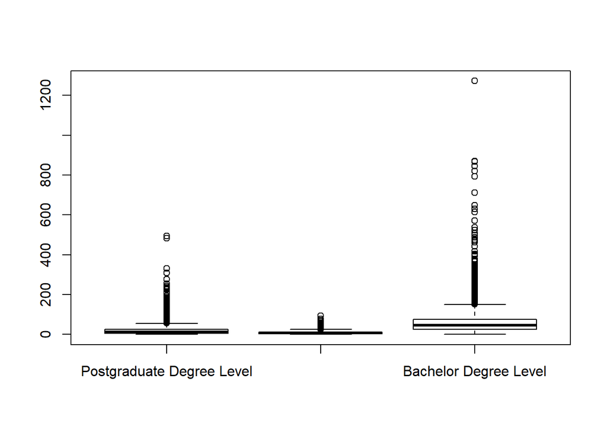

```r
# Refactor levels of education
edu_uni$Ed_level <- factor(edu_uni$Ed_level,
                           labels = c("Postgraduate Degree Level", "Graduate Diploma and Graduate Certificate Level",
                                      "Bachelor Degree Level"),
                           levels = c("Postgraduate Degree Level", "Graduate Diploma and Graduate Certificate Level",
                                      "Bachelor Degree Level"))
boxplot(edu_uni$People ~ edu_uni$Ed_level)
```

```r
#let's mutate post and grad into one (total counts)
edu_uni_tot <- education %>%  mutate(Post = (education$`Postgraduate Degree Level` + education$`Graduate Diploma and Graduate Certificate Level`),
                                     UnderGrad = education$`Bachelor Degree Level`) %>%
                              select(SA1, Post, UnderGrad)
head(edu_uni_tot)
```

| SA1 | Post | UnderGrad |
| --- | --- | --- |
| 2100101 | 34 | 44 |
| 2100102 | 0 | 24 |
| 2100105 | 14 | 30 |
| 2100106 | 29 | 69 |
| 2100107 | 20 | 45 |
| 2100108 | 37 | 67 |

```r
edu_uni_tot$SA1 <- as.numeric(edu_uni_tot$SA1)
edu_uni_tot2 <- edu_uni_tot %>% left_join(geo_lookup[, c('SA1_7DIG16','LGA_NAME17')], by = c('SA1' = 'SA1_7DIG16'))
head(edu_uni_tot2)
```

| SA1 | Post | UnderGrad | LGA_NAME17 |
| --- | --- | --- | --- |
| 2100101 | 34 | 44 | Ballarat (C) |
| 2100102 | 0 | 24 | Ballarat (C) |
| 2100105 | 14 | 30 | Ballarat (C) |
| 2100106 | 29 | 69 | Ballarat (C) |
| 2100107 | 20 | 45 | Ballarat (C) |
| 2100108 | 37 | 67 | Ballarat (C) |

```r
glimpse(edu_uni_tot2)
```

```
## Observations: 14,386
## Variables: 4
## $ SA1        <dbl> 2100101, 2100102, 2100105, 2100106, 2100107, 210010...
## $ Post       <dbl> 34, 0, 14, 29, 20, 37, 35, 27, 26, 19, 20, 29, 21, ...
## $ UnderGrad  <dbl> 44, 24, 30, 69, 45, 67, 48, 63, 37, 50, 42, 98, 42,...
## $ LGA_NAME17 <chr> "Ballarat (C)", "Ballarat (C)", "Ballarat (C)", "Ba...
```

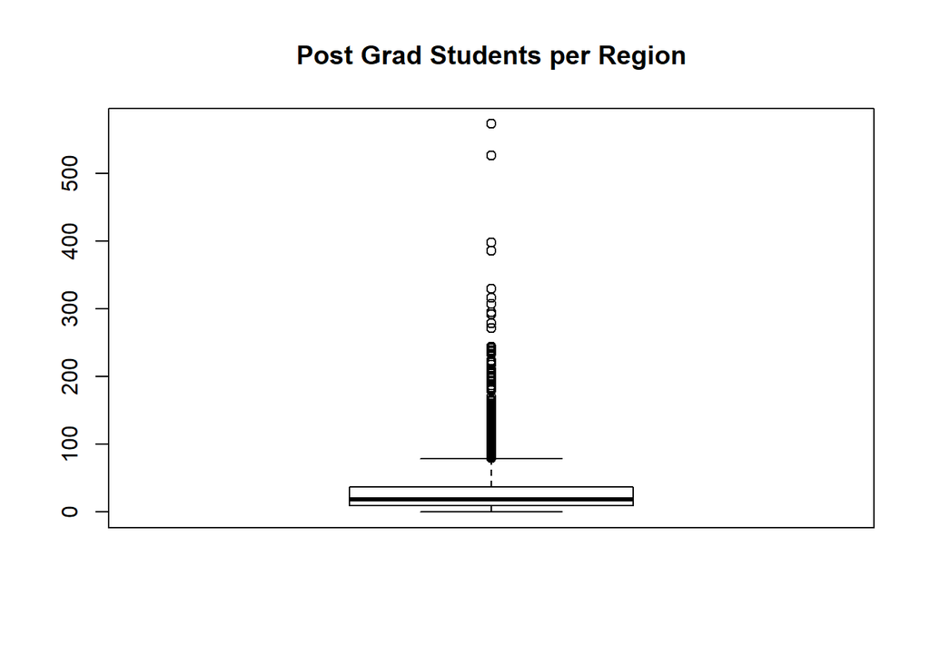

```r
# spread then mutate, will be easier
box_post_tot <- boxplot(edu_uni_tot2[,2], main  = 'Post Grad Students per Region')
```

```r
length(box_post_tot$out) # 532 outliers for post grad
```

```
## [1] 532
```

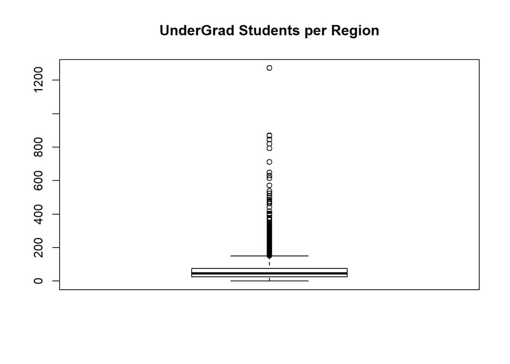

```r
box_under_tot <- boxplot(edu_uni_tot2[,3], main = 'UnderGrad Students per Region')
```

```r
length(box_under_tot$out) # 454 outliers for under grad
```

```
## [1] 454
```

```r
#let's mutate post and grad into one (but as a proportion of the total)
edu_uni_prop <- education %>%  mutate(Post = (education$`Postgraduate Degree Level` + education$`Graduate Diploma and Graduate Certificate Level`)/education$Total,
                                      UnderGrad = education$`Bachelor Degree Level`/education$Total) %>%
                                select(SA1, Post, UnderGrad)
head(edu_uni_prop)
```

| SA1 | Post | UnderGrad |
| --- | --- | --- |
| 2100101 | 0.07906977 | 0.10232558 |
| 2100102 | 0.00000000 | 0.11059908 |
| 2100105 | 0.04713805 | 0.10101010 |
| 2100106 | 0.05141844 | 0.12234043 |
| 2100107 | 0.05479452 | 0.12328767 |
| 2100108 | 0.05433186 | 0.09838473 |

```r
glimpse(edu_uni_prop)
```

```
## Observations: 14,073
## Variables: 3
## $ SA1       <chr> "2100101", "2100102", "2100105", "2100106", "2100107...
## $ Post      <dbl> 0.07906977, 0.00000000, 0.04713805, 0.05141844, 0.05...
## $ UnderGrad <dbl> 0.10232558, 0.11059908, 0.10101010, 0.12234043, 0.12...
```

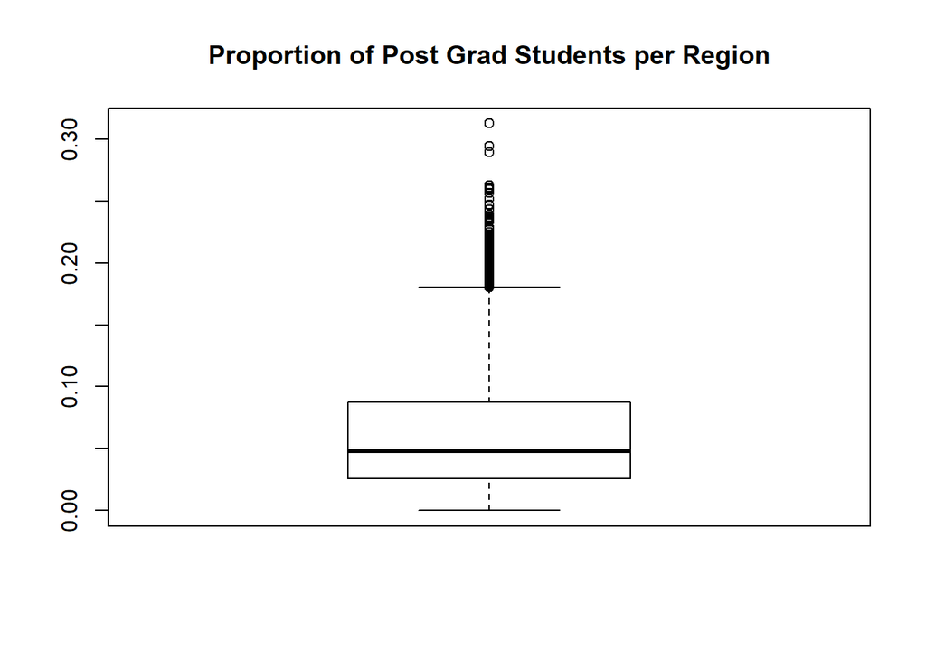

```r
edu_uni_prop$SA1 <- as.numeric(edu_uni_prop$SA1)
edu_uni_prop2 <- edu_uni_prop %>% left_join(geo_lookup[, c('SA1_7DIG16','LGA_NAME17')], by = c('SA1' = 'SA1_7DIG16'))
# spread then mutate, will be easier
box_post_prop <- boxplot(edu_uni_prop2[,2], main = 'Proportion of Post Grad Students per Region')
```

```r
length(box_post_prop$out) # 203 outliers, significant drop in outliers when you take into account the proportion
```

```
## [1] 203
```

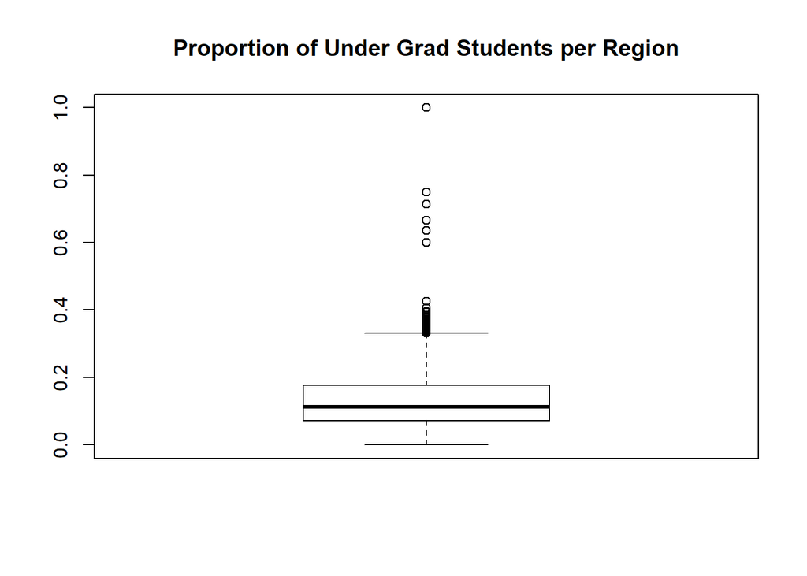

```r
box_under_prop <- boxplot(edu_uni_prop2[,3], main = 'Proportion of Under Grad Students per Region')
```

```r
length(box_under_prop$out) # 122 outliers
```

```
## [1] 122
```

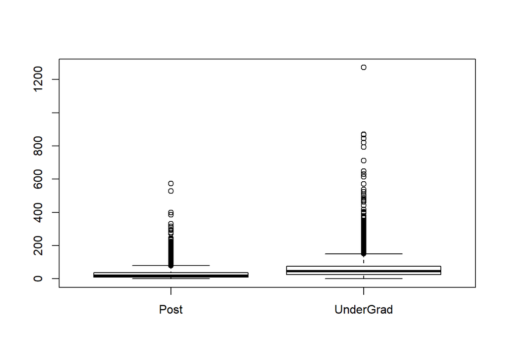

```r
boxplot(edu_uni_tot2[,2:3])
```

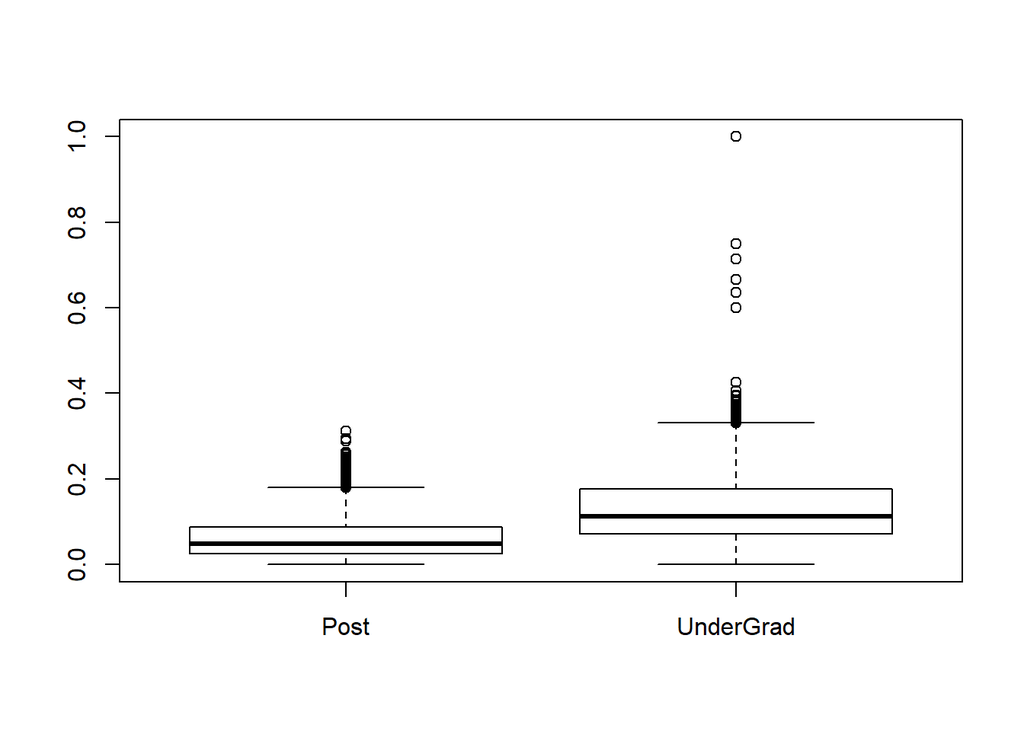

```r
boxplot(edu_uni_prop2[,2:3]) # both visuals
```

```r
# finding proportions drastically reduces the count of outliers

### Now what to do with outliers?

####################################
#LGA based outlier work

# Post grad and Under Grad count
edu_uni_lga <- edu_by_LGA %>% filter(Ed_level <= 'Bachelor Degree Level')
summary(edu_uni_lga)
```

```
##      LGA                                                       Ed_level
##  Length:246         Postgraduate Degree Level                      :82
##  Class :character   Graduate Diploma and Graduate Certificate Level:82
##  Mode  :character   Bachelor Degree Level                          :82
##                     Advanced Diploma and Diploma Level             : 0
##                     Certificate III & IV Level                     : 0
##                     Secondary Education - Years 10 and above       : 0
##                     (Other)                                        : 0
##    PeopleSum
##  Min.   :    0
##  1st Qu.:  385
##  Median : 1506
##  Mean   : 4816
##  3rd Qu.: 4515
##  Max.   :42145
##
```

```r
glimpse(edu_uni_lga)
```

```
## Observations: 246
## Variables: 3
## $ LGA       <chr> "Alpine (S)", "Alpine (S)", "Alpine (S)", "Ararat (R...
## $ Ed_level  <ord> Postgraduate Degree Level, Graduate Diploma and Grad...
## $ PeopleSum <dbl> 223, 297, 1257, 111, 157, 813, 2714, 2268, 10556, 73...
```

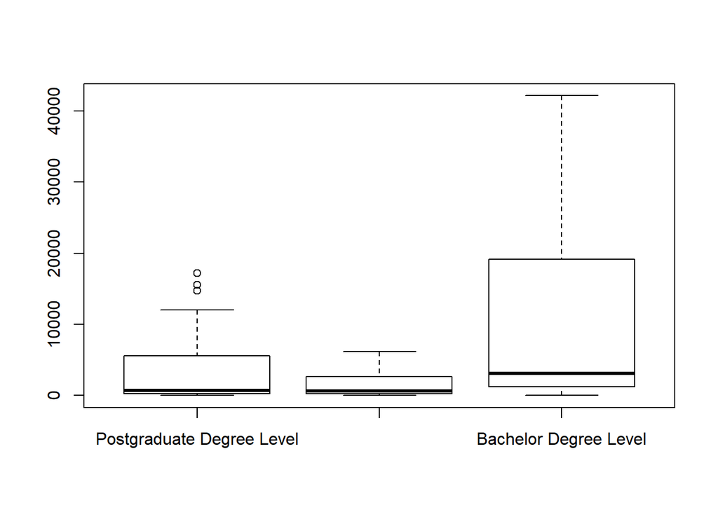

```r
# Refactor levels of education
edu_uni_lga$Ed_level <- factor(edu_uni_lga$Ed_level,
                               labels = c("Postgraduate Degree Level", "Graduate Diploma and Graduate Certificate Level",
                                          "Bachelor Degree Level"),
                               levels = c("Postgraduate Degree Level", "Graduate Diploma and Graduate Certificate Level",
                                          "Bachelor Degree Level"))
boxplot(edu_uni_lga$PeopleSum~edu_uni_lga$Ed_level)
```

```r
#let's mutate post and grad into one (total counts)
glimpse(education)
```

```
## Observations: 14,073
## Variables: 13
## $ SA1                                               <chr> "2100101", "...
## $ `Postgraduate Degree Level`                       <dbl> 22, 0, 9, 13...
## $ `Graduate Diploma and Graduate Certificate Level` <dbl> 12, 0, 5, 16...
## $ `Bachelor Degree Level`                           <dbl> 44, 24, 30, ...
## $ `Advanced Diploma and Diploma Level`              <dbl> 31, 16, 31, ...
## $ `Certificate III & IV Level`                      <dbl> 61, 23, 46, ...
## $ `Secondary Education - Years 10 and above`        <dbl> 111, 58, 86,...
## $ `Certificate I & II Level`                        <dbl> 0, 0, 0, 0, ...
## $ `Secondary Education - Years 9 and below`         <dbl> 25, 52, 19, ...
## $ `Supplementary Codes`                             <dbl> 10, 3, 11, 8...
## $ `Not stated`                                      <dbl> 32, 21, 31, ...
## $ `Not applicable`                                  <dbl> 82, 22, 36, ...
## $ Total                                             <dbl> 430, 217, 29...
```

```r
edu_uni_tot_lga <- education %>%  mutate(Post = (education$`Postgraduate Degree Level` + education$`Graduate Diploma and Graduate Certificate Level`),
                                         UnderGrad = education$`Bachelor Degree Level`) %>% select(SA1, Post, UnderGrad)

head(edu_uni_tot)
```

| SA1 | Post | UnderGrad |
| --- | --- | --- |
| 2100101 | 34 | 44 |
| 2100102 | 0 | 24 |
| 2100105 | 14 | 30 |
| 2100106 | 29 | 69 |
| 2100107 | 20 | 45 |
| 2100108 | 37 | 67 |

```r
edu_uni_tot$SA1 <- as.numeric(edu_uni_tot$SA1)
edu_uni_tot2 <- edu_uni_tot %>% left_join(geo_lookup[, c('SA1_7DIG16','LGA_NAME17')], by = c('SA1' = 'SA1_7DIG16'))
head(edu_uni_tot2)
```

| SA1 | Post | UnderGrad | LGA_NAME17 |
| --- | --- | --- | --- |
| 2100101 | 34 | 44 | Ballarat (C) |
| 2100102 | 0 | 24 | Ballarat (C) |
| 2100105 | 14 | 30 | Ballarat (C) |
| 2100106 | 29 | 69 | Ballarat (C) |
| 2100107 | 20 | 45 | Ballarat (C) |
| 2100108 | 37 | 67 | Ballarat (C) |

```r
glimpse(edu_uni_tot2)
```

```
## Observations: 14,386
## Variables: 4
## $ SA1        <dbl> 2100101, 2100102, 2100105, 2100106, 2100107, 210010...
## $ Post       <dbl> 34, 0, 14, 29, 20, 37, 35, 27, 26, 19, 20, 29, 21, ...
## $ UnderGrad  <dbl> 44, 24, 30, 69, 45, 67, 48, 63, 37, 50, 42, 98, 42,...
## $ LGA_NAME17 <chr> "Ballarat (C)", "Ballarat (C)", "Ballarat (C)", "Ba...
```

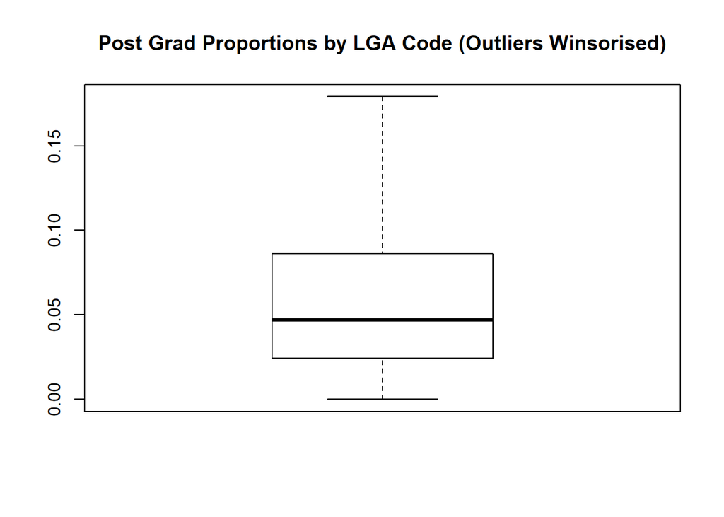

```r
################################
# Handling Outliers
################################

# Replace NAs with 0 values in the proportions (NA's occured due to 0/0 mutate)
edu_uni_prop2[which(is.na(edu_uni_prop2$Post)),] <- 0
edu_uni_prop2[which(is.na(edu_uni_prop2$UnderGrad)),] <- 0

cap <- function(x){
  quantiles <- quantile( x, c(.05, 0.25, 0.75, .95 ) )
  x[ x < quantiles[2] - 1.5*IQR(x) ] <- quantiles[1]
  x[ x > quantiles[3] + 1.5*IQR(x) ] <- quantiles[4]
  x
} # from Module 6 of MATH 2349, credit to Dr Anil Dolgun

post_cap <- cap(edu_uni_prop2$Post)
boxplot(post_cap, main = 'Post Grad Proportions by LGA Code (Outliers Winsorised)')
```

```r
summary(post_cap)
```

```
##    Min. 1st Qu.  Median    Mean 3rd Qu.    Max.
## 0.00000 0.02429 0.04680 0.05817 0.08623 0.17908
```

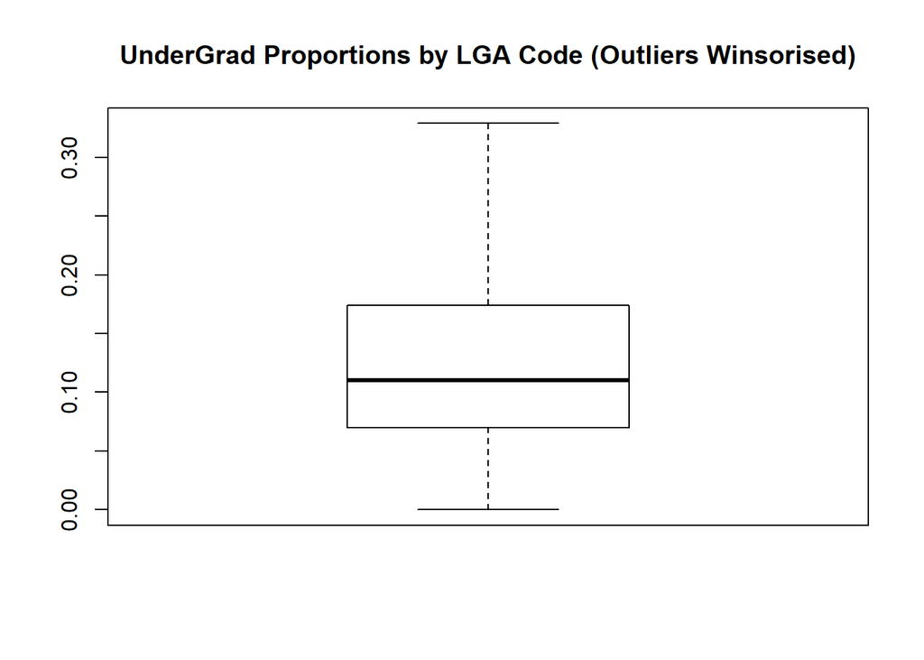

```r
under_cap <- cap(edu_uni_prop2$UnderGrad)
boxplot(under_cap, main = 'UnderGrad Proportions by LGA Code (Outliers Winsorised)')
```

```r
summary(under_cap)
```

```
##    Min. 1st Qu.  Median    Mean 3rd Qu.    Max.
##  0.0000  0.0701  0.1103  0.1253  0.1739  0.3291
```

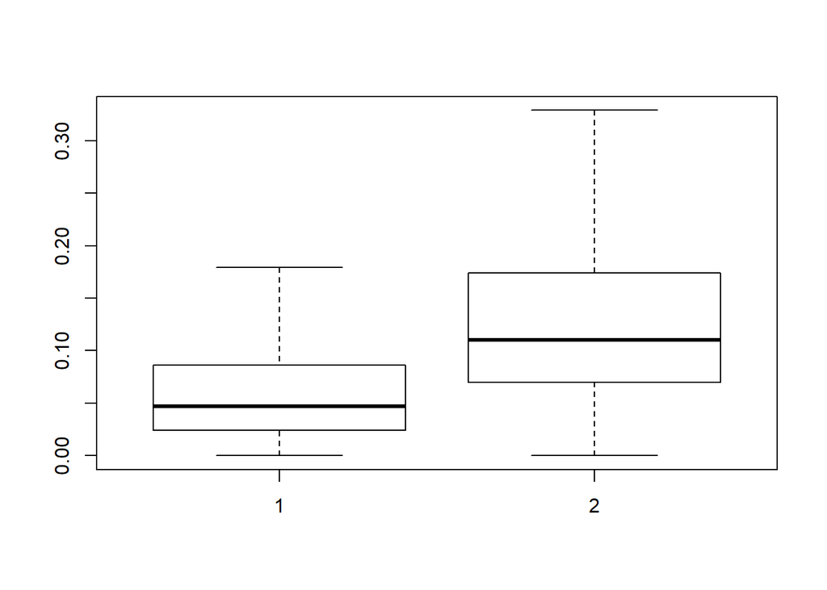

```r
boxplot(post_cap, under_cap)
```

```r
#I am great
```